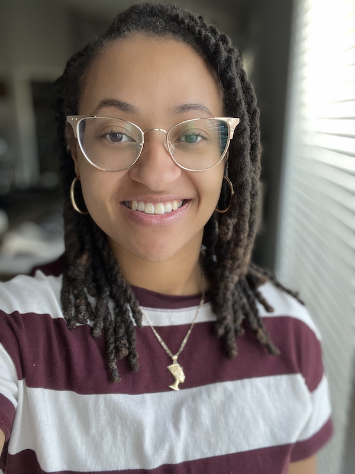

# Sierra Davis

## About Me

Hi! I am a Data Scientist working in the healthcare industry. I currently focus on ML algorithms to help identify meaningful PCP matches for patients. I have a background in medical informatics programming, data integration and data analysis. I have several years of experience designing, developing, and owning analyses supporting use cases such as quality improvement, statistical analysis, and research. As a leader, I continuously develop my skills to increase my capabilities to serve my stakeholders and team.

I am also passionate about supporting initiatives that strive to improve diversity within the data science community. Outside of work, I love to spend time with my family. Feel free to contact me to connect.

## Education

- MBA in Data Science, Rockhurst University, 2017
- BS in Management Information Systems, Kansas State University, 2013

## Work Experience

- Data Scientist, 2022-Present – Nuna Inc. (Remote)
- Data Scientist II, 2022-2022 – Children’s Mercy Research Institute (Kansas City, MO)
- Data Science Research Associate, 2018-2022 – Children’s Mercy Research Institute (Kansas City, MO)
- Data Scientist, 2017-2018 – Cigna (Remote)
- Medical Informatics Programmer II, 2015-2017 – Children’s Mercy Hospital (Kansas City, MO)

## Skills

- Data Science Methods: Classification, Regression, Clustering, NLP, Visualization
- Programming Languages: R, SQL, Python
- Software and Tools: RStudio, Jupyter Notebooks, SQL Server, Tableau, SAP Business Objects, Jira, Git

## Talks

- Comparing the Treatment Regimen of Newly Diagnosed Pediatric Leukemia Patients, useR! 2020 [[Poster]](https://github.com/sierradavis/useR2020-Pediatric-Leukemia/blob/master/AACR%20Fall%202018%20Poster.pdf)[[Presentation]](https://youtu.be/qToKh1qev2c)
- Longitudinal Data Analysis, Kansas City R Meetup [[Slides]](https://sierradavis.github.io/r_meetup_march/#1)
- Applying Data Science Methods to the EHR, Frontiers Informatic Meetup [[Slides]](https://sierradavis.github.io/dec-frontiers-informatics/#1)
- Ethical Data Strategies for Design and Development, American Congress of Rehabilitation Medicine, Virtual

## Awards and Recognition

- RStudio Global Conference Diversity Scholarship, 2021
- Science to Art Competition - BioNexus KC, 2020

## Service

- Ethical AI Council Member - Center for Practical Bioethics
- W.E.B Dubois Learning Center Math Tutor